# Exploration of loan data from prosper

## Data Overview.

### This dataset contains 113,937 loans with 81 variables on each loan, including loan amount,borrowerAPR or interest rate, loan status,borrower income,debt to income ratio,employmentstatusduration and many others.

```python
## importing the necessary libraries.
import numpy as np
import pandas as pd
import matplotlib.pyplot as plt
import seaborn as sns
%matplotlib inline
```

```python
## importing the prosperloandataset into a pandas dataframe.
prosper_loan = pd.read_csv('prosperLoanData.csv')
```

```python
##checking the first 10 data
prosper_loan.head(10)
```

|  | ListingKey | ListingNumber | ListingCreationDate | CreditGrade | Term | LoanStatus | ClosedDate | BorrowerAPR | BorrowerRate | LenderYield | ... | LP_ServiceFees | LP_CollectionFees | LP_GrossPrincipalLoss | LP_NetPrincipalLoss | LP_NonPrincipalRecoverypayments | PercentFunded | Recommendations | InvestmentFromFriendsCount | InvestmentFromFriendsAmount | Investors |
| --- | --- | --- | --- | --- | --- | --- | --- | --- | --- | --- | --- | --- | --- | --- | --- | --- | --- | --- | --- | --- | --- |
| 0 | 1021339766868145413AB3B | 193129 | 2007-08-26 19:09:29.263000000 | C | 36 | Completed | 2009-08-14 00:00:00 | 0.16516 | 0.1580 | 0.1380 | ... | -133.18 | 0.0 | 0.0 | 0.0 | 0.0 | 1.0 | 0 | 0 | 0.0 | 258 |
| 1 | 10273602499503308B223C1 | 1209647 | 2014-02-27 08:28:07.900000000 | NaN | 36 | Current | NaN | 0.12016 | 0.0920 | 0.0820 | ... | 0.00 | 0.0 | 0.0 | 0.0 | 0.0 | 1.0 | 0 | 0 | 0.0 | 1 |
| 2 | 0EE9337825851032864889A | 81716 | 2007-01-05 15:00:47.090000000 | HR | 36 | Completed | 2009-12-17 00:00:00 | 0.28269 | 0.2750 | 0.2400 | ... | -24.20 | 0.0 | 0.0 | 0.0 | 0.0 | 1.0 | 0 | 0 | 0.0 | 41 |
| 3 | 0EF5356002482715299901A | 658116 | 2012-10-22 11:02:35.010000000 | NaN | 36 | Current | NaN | 0.12528 | 0.0974 | 0.0874 | ... | -108.01 | 0.0 | 0.0 | 0.0 | 0.0 | 1.0 | 0 | 0 | 0.0 | 158 |
| 4 | 0F023589499656230C5E3E2 | 909464 | 2013-09-14 18:38:39.097000000 | NaN | 36 | Current | NaN | 0.24614 | 0.2085 | 0.1985 | ... | -60.27 | 0.0 | 0.0 | 0.0 | 0.0 | 1.0 | 0 | 0 | 0.0 | 20 |
| 5 | 0F05359734824199381F61D | 1074836 | 2013-12-14 08:26:37.093000000 | NaN | 60 | Current | NaN | 0.15425 | 0.1314 | 0.1214 | ... | -25.33 | 0.0 | 0.0 | 0.0 | 0.0 | 1.0 | 0 | 0 | 0.0 | 1 |
| 6 | 0F0A3576754255009D63151 | 750899 | 2013-04-12 09:52:56.147000000 | NaN | 36 | Current | NaN | 0.31032 | 0.2712 | 0.2612 | ... | -22.95 | 0.0 | 0.0 | 0.0 | 0.0 | 1.0 | 0 | 0 | 0.0 | 1 |
| 7 | 0F1035772717087366F9EA7 | 768193 | 2013-05-05 06:49:27.493000000 | NaN | 36 | Current | NaN | 0.23939 | 0.2019 | 0.1919 | ... | -69.21 | 0.0 | 0.0 | 0.0 | 0.0 | 1.0 | 0 | 0 | 0.0 | 1 |
| 8 | 0F043596202561788EA13D5 | 1023355 | 2013-12-02 10:43:39.117000000 | NaN | 36 | Current | NaN | 0.07620 | 0.0629 | 0.0529 | ... | -16.77 | 0.0 | 0.0 | 0.0 | 0.0 | 1.0 | 0 | 0 | 0.0 | 1 |
| 9 | 0F043596202561788EA13D5 | 1023355 | 2013-12-02 10:43:39.117000000 | NaN | 36 | Current | NaN | 0.07620 | 0.0629 | 0.0529 | ... | -16.77 | 0.0 | 0.0 | 0.0 | 0.0 | 1.0 | 0 | 0 | 0.0 | 1 |

10 rows × 81 columns

```python
## checking my dataset at random.
prosper_loan.sample(15)
```

|  | ListingKey | ListingNumber | ListingCreationDate | CreditGrade | Term | LoanStatus | ClosedDate | BorrowerAPR | BorrowerRate | LenderYield | ... | LP_ServiceFees | LP_CollectionFees | LP_GrossPrincipalLoss | LP_NetPrincipalLoss | LP_NonPrincipalRecoverypayments | PercentFunded | Recommendations | InvestmentFromFriendsCount | InvestmentFromFriendsAmount | Investors |
| --- | --- | --- | --- | --- | --- | --- | --- | --- | --- | --- | --- | --- | --- | --- | --- | --- | --- | --- | --- | --- | --- |
| 45124 | AC3535875599367050F6FD2 | 870886 | 2013-08-15 09:01:31.050000000 | NaN | 36 | Current | NaN | 0.08930 | 0.0759 | 0.0659 | ... | -47.25 | 0.00 | 0.00 | 0.00 | 0.00 | 1.0 | 0 | 0 | 0.0 | 213 |
| 74735 | C81C358639271375657364A | 872757 | 2013-08-18 07:02:26.330000000 | NaN | 60 | Current | NaN | 0.21566 | 0.1914 | 0.1814 | ... | -34.40 | 0.00 | 0.00 | 0.00 | 0.00 | 1.0 | 0 | 0 | 0.0 | 1 |
| 35747 | B2B43397467654265765043 | 190689 | 2007-08-21 14:45:59.113000000 | C | 36 | Chargedoff | 2008-12-01 00:00:00 | 0.15803 | 0.1509 | 0.1409 | ... | -30.01 | 0.00 | 3064.13 | 3064.13 | 0.00 | 1.0 | 2 | 1 | 60.0 | 99 |
| 39883 | 3BBF3476734735337581435 | 447865 | 2010-02-23 13:46:24.580000000 | NaN | 36 | Completed | 2013-03-10 00:00:00 | 0.17018 | 0.1485 | 0.1385 | ... | -198.93 | 0.00 | 0.00 | 0.00 | 0.00 | 1.0 | 0 | 0 | 0.0 | 359 |
| 37740 | C3D3349774238058888A8D5 | 480587 | 2010-10-19 18:14:59.143000000 | NaN | 36 | Completed | 2011-01-14 00:00:00 | 0.38723 | 0.3500 | 0.3400 | ... | -12.67 | 0.00 | 0.00 | 0.00 | 0.00 | 1.0 | 0 | 0 | 0.0 | 107 |
| 102261 | F887360180320033498A6FF | 1180328 | 2014-02-05 11:42:07.600000000 | NaN | 36 | Current | NaN | 0.22108 | 0.1840 | 0.1740 | ... | 0.00 | 0.00 | 0.00 | 0.00 | 0.00 | 1.0 | 0 | 0 | 0.0 | 1 |
| 28744 | 31123604418153894946196 | 1230209 | 2014-03-05 07:01:54.883000000 | NaN | 36 | Current | NaN | 0.20869 | 0.1715 | 0.1615 | ... | 0.00 | 0.00 | 0.00 | 0.00 | 0.00 | 1.0 | 0 | 0 | 0.0 | 124 |
| 984 | 479235384611858318DBDF2 | 556779 | 2012-02-07 12:55:44.287000000 | NaN | 36 | Current | NaN | 0.06828 | 0.0649 | 0.0549 | ... | -69.80 | 0.00 | 0.00 | 0.00 | 0.00 | 1.0 | 0 | 0 | 0.0 | 107 |
| 48547 | 9A943393098929203E469AF | 158546 | 2007-06-26 11:10:01.627000000 | E | 36 | Chargedoff | 2009-02-03 00:00:00 | 0.24396 | 0.2289 | 0.2189 | ... | -23.76 | -122.06 | 2583.19 | 2558.56 | 1842.39 | 1.0 | 0 | 0 | 0.0 | 91 |
| 19973 | 69163498920460879DA008D | 484415 | 2010-11-15 13:53:14.313000000 | NaN | 36 | Completed | 2011-12-09 00:00:00 | 0.07990 | 0.0765 | 0.0665 | ... | -44.59 | 0.00 | 0.00 | 0.00 | 0.00 | 1.0 | 0 | 0 | 0.0 | 112 |
| 21474 | DA7A34003408809691475A4 | 200236 | 2007-09-10 21:24:10.690000000 | B | 36 | Defaulted | 2008-07-23 00:00:00 | 0.29776 | 0.2900 | 0.2600 | ... | -72.70 | 0.00 | 16336.48 | 16336.47 | 0.00 | 1.0 | 0 | 0 | 0.0 | 183 |
| 37245 | EFD035443113422487825C6 | 575913 | 2012-04-05 14:42:15.420000000 | NaN | 36 | Current | NaN | 0.35797 | 0.3177 | 0.3077 | ... | -57.83 | 0.00 | 0.00 | 0.00 | 0.00 | 1.0 | 0 | 0 | 0.0 | 14 |
| 108944 | E5D935304975491749D5A8B | 538853 | 2011-11-13 19:19:42.063000000 | NaN | 36 | Current | NaN | 0.29510 | 0.2599 | 0.2499 | ... | -159.53 | 0.00 | 0.00 | 0.00 | 0.00 | 1.0 | 0 | 0 | 0.0 | 11 |
| 108708 | AB1C3565924798757F8BB33 | 687151 | 2012-12-14 08:54:20.923000000 | NaN | 60 | Current | NaN | 0.12216 | 0.1000 | 0.0900 | ... | -175.02 | 0.00 | 0.00 | 0.00 | 0.00 | 1.0 | 0 | 0 | 0.0 | 160 |
| 106861 | F46A35997394682433A9F24 | 1081837 | 2014-01-03 15:36:59.747000000 | NaN | 36 | Current | NaN | 0.32446 | 0.2850 | 0.2750 | ... | -8.49 | 0.00 | 0.00 | 0.00 | 0.00 | 1.0 | 0 | 0 | 0.0 | 3 |

15 rows × 81 columns

```python
## checking the last 10 data.
prosper_loan.tail(10)
```

|  | ListingKey | ListingNumber | ListingCreationDate | CreditGrade | Term | LoanStatus | ClosedDate | BorrowerAPR | BorrowerRate | LenderYield | ... | LP_ServiceFees | LP_CollectionFees | LP_GrossPrincipalLoss | LP_NetPrincipalLoss | LP_NonPrincipalRecoverypayments | PercentFunded | Recommendations | InvestmentFromFriendsCount | InvestmentFromFriendsAmount | Investors |
| --- | --- | --- | --- | --- | --- | --- | --- | --- | --- | --- | --- | --- | --- | --- | --- | --- | --- | --- | --- | --- | --- |
| 113927 | E3433419834735803891976 | 322787 | 2008-04-30 21:25:19.670000000 | AA | 36 | Completed | 2011-05-09 00:00:00 | 0.07469 | 0.0679 | 0.0579 | ... | -68.47 | 0.0 | 0.0 | 0.0 | 0.0 | 1.0 | 2 | 0 | 0.0 | 194 |
| 113928 | E34935176664905343E01EA | 510097 | 2011-06-06 19:02:44.443000000 | NaN | 36 | Completed | 2011-09-19 00:00:00 | 0.22362 | 0.1899 | 0.1799 | ... | -4.41 | 0.0 | 0.0 | 0.0 | 0.0 | 1.0 | 0 | 0 | 0.0 | 25 |
| 113929 | E3553583161337791FCB87F | 830413 | 2013-07-06 17:40:01.657000000 | NaN | 36 | Completed | 2014-02-07 00:00:00 | 0.30285 | 0.2639 | 0.2539 | ... | -6.54 | 0.0 | 0.0 | 0.0 | 0.0 | 1.0 | 0 | 0 | 0.0 | 26 |
| 113930 | E35D3584034795373BCD69A | 831523 | 2013-07-08 10:24:49.700000000 | NaN | 36 | Current | NaN | 0.20053 | 0.1639 | 0.1539 | ... | -16.51 | 0.0 | 0.0 | 0.0 | 0.0 | 1.0 | 0 | 0 | 0.0 | 52 |
| 113931 | E36F36005339663245C20F8 | 1141292 | 2014-01-16 20:13:08.040000000 | NaN | 60 | Current | NaN | 0.15016 | 0.1274 | 0.1174 | ... | -21.23 | 0.0 | 0.0 | 0.0 | 0.0 | 1.0 | 0 | 0 | 0.0 | 1 |
| 113932 | E6D9357655724827169606C | 753087 | 2013-04-14 05:55:02.663000000 | NaN | 36 | Current | NaN | 0.22354 | 0.1864 | 0.1764 | ... | -75.58 | 0.0 | 0.0 | 0.0 | 0.0 | 1.0 | 0 | 0 | 0.0 | 1 |
| 113933 | E6DB353036033497292EE43 | 537216 | 2011-11-03 20:42:55.333000000 | NaN | 36 | FinalPaymentInProgress | NaN | 0.13220 | 0.1110 | 0.1010 | ... | -30.05 | 0.0 | 0.0 | 0.0 | 0.0 | 1.0 | 0 | 0 | 0.0 | 22 |
| 113934 | E6E13596170052029692BB1 | 1069178 | 2013-12-13 05:49:12.703000000 | NaN | 60 | Current | NaN | 0.23984 | 0.2150 | 0.2050 | ... | -16.91 | 0.0 | 0.0 | 0.0 | 0.0 | 1.0 | 0 | 0 | 0.0 | 119 |
| 113935 | E6EB3531504622671970D9E | 539056 | 2011-11-14 13:18:26.597000000 | NaN | 60 | Completed | 2013-08-13 00:00:00 | 0.28408 | 0.2605 | 0.2505 | ... | -235.05 | 0.0 | 0.0 | 0.0 | 0.0 | 1.0 | 0 | 0 | 0.0 | 274 |
| 113936 | E6ED3600409833199F711B7 | 1140093 | 2014-01-15 09:27:37.657000000 | NaN | 36 | Current | NaN | 0.13189 | 0.1039 | 0.0939 | ... | -1.70 | 0.0 | 0.0 | 0.0 | 0.0 | 1.0 | 0 | 0 | 0.0 | 1 |

10 rows × 81 columns

### Assessment

#### Programmatic Assessment

```python
## shape of our dataset
prosper_loan.shape
```

```
(113937, 81)
```

This dataset has 113937 rows and 81 columns

```python
## Checking the data types of each variable and also how many rows each variable has.
prosper_loan.info()
```

```
<class 'pandas.core.frame.DataFrame'>
RangeIndex: 113937 entries, 0 to 113936
Data columns (total 81 columns):
 #   Column                               Non-Null Count   Dtype
---  ------                               --------------   -----
 0   ListingKey                           113937 non-null  object
 1   ListingNumber                        113937 non-null  int64
 2   ListingCreationDate                  113937 non-null  object
 3   CreditGrade                          28953 non-null   object
 4   Term                                 113937 non-null  int64
 5   LoanStatus                           113937 non-null  object
 6   ClosedDate                           55089 non-null   object
 7   BorrowerAPR                          113912 non-null  float64
 8   BorrowerRate                         113937 non-null  float64
 9   LenderYield                          113937 non-null  float64
```

[output cut: 73 more lines]

The variables; CreditGrade,ClosedDate,GroupKey,TotalProsperLoans,TotalProsperPaymentsBilled,OntimeProsperPayments,ProsperPaymentsLessThanOneMonthLate,ProsperPaymentsOneMonthPlusLate,ProsperPrincipalBorrowed,ProsperPrincipalOutstanding,ScorexChangeAtTimeOfListing,LoanFirstDefaultedCycleNumber have alot of missing values.

```python
## Dropping CreditGrade,ClosedDate,GroupKey,TotalProsperLoans,TotalProsperPaymentsBilled,ProsperPaymentsLessThanOneMonthLate,ProsperPrincipalBorrowed,ProsperPrincipalOutstanding,ScorexChangeAtTimeOfListing and LoanFirstDefaultedCycleNumber.
prosper_loan.drop(prosper_loan.columns[[3,6,23,51,52,54,56,57,58,60]], axis = 1, inplace = True)
```

```python
## Checking if the columns are dropped.
print(prosper_loan.columns)
```

```
Index(['ListingKey', 'ListingNumber', 'ListingCreationDate', 'Term',
       'LoanStatus', 'BorrowerAPR', 'BorrowerRate', 'LenderYield',
       'EstimatedEffectiveYield', 'EstimatedLoss', 'EstimatedReturn',
       'ProsperRating (numeric)', 'ProsperRating (Alpha)', 'ProsperScore',
       'ListingCategory (numeric)', 'BorrowerState', 'Occupation',
       'EmploymentStatus', 'EmploymentStatusDuration', 'IsBorrowerHomeowner',
       'CurrentlyInGroup', 'DateCreditPulled', 'CreditScoreRangeLower',
       'CreditScoreRangeUpper', 'FirstRecordedCreditLine',
       'CurrentCreditLines', 'OpenCreditLines', 'TotalCreditLinespast7years',
       'OpenRevolvingAccounts', 'OpenRevolvingMonthlyPayment',
       'InquiriesLast6Months', 'TotalInquiries', 'CurrentDelinquencies',
       'AmountDelinquent', 'DelinquenciesLast7Years',
       'PublicRecordsLast10Years', 'PublicRecordsLast12Months',
       'RevolvingCreditBalance', 'BankcardUtilization',
       'AvailableBankcardCredit', 'TotalTrades',
       'TradesNeverDelinquent (percentage)', 'TradesOpenedLast6Months',
       'DebtToIncomeRatio', 'IncomeRange', 'IncomeVerifiable',
       'StatedMonthlyIncome', 'LoanKey', 'OnTimeProsperPayments',
       'ProsperPaymentsOneMonthPlusLate', 'LoanCurrentDaysDelinquent',
       'LoanMonthsSinceOrigination', 'LoanNumber', 'LoanOriginalAmount',
       'LoanOriginationDate', 'LoanOriginationQuarter', 'MemberKey',
       'MonthlyLoanPayment', 'LP_CustomerPayments',
       'LP_CustomerPrincipalPayments', 'LP_InterestandFees', 'LP_ServiceFees',
       'LP_CollectionFees', 'LP_GrossPrincipalLoss', 'LP_NetPrincipalLoss',
       'LP_NonPrincipalRecoverypayments', 'PercentFunded', 'Recommendations',
       'InvestmentFromFriendsCount', 'InvestmentFromFriendsAmount',
       'Investors'],
      dtype='object')
```

Note: I didnot remove OntimeProsperPayments and ProsperPaymentsOneMonthPlusLate because i will be exploring them.

```python
## Descriptive statistics of numerical variables in our dataset.
prosper_loan.describe()
```

|  | ListingNumber | Term | BorrowerAPR | BorrowerRate | LenderYield | EstimatedEffectiveYield | EstimatedLoss | EstimatedReturn | ProsperRating (numeric) | ProsperScore | ... | LP_ServiceFees | LP_CollectionFees | LP_GrossPrincipalLoss | LP_NetPrincipalLoss | LP_NonPrincipalRecoverypayments | PercentFunded | Recommendations | InvestmentFromFriendsCount | InvestmentFromFriendsAmount | Investors |
| --- | --- | --- | --- | --- | --- | --- | --- | --- | --- | --- | --- | --- | --- | --- | --- | --- | --- | --- | --- | --- | --- |
| count | 1.139370e+05 | 113937.000000 | 113912.000000 | 113937.000000 | 113937.000000 | 84853.000000 | 84853.000000 | 84853.000000 | 84853.000000 | 84853.000000 | ... | 113937.000000 | 113937.000000 | 113937.000000 | 113937.000000 | 113937.000000 | 113937.000000 | 113937.000000 | 113937.000000 | 113937.000000 | 113937.000000 |
| mean | 6.278857e+05 | 40.830248 | 0.218828 | 0.192764 | 0.182701 | 0.168661 | 0.080306 | 0.096068 | 4.072243 | 5.950067 | ... | -54.725641 | -14.242698 | 700.446342 | 681.420499 | 25.142686 | 0.998584 | 0.048027 | 0.023460 | 16.550751 | 80.475228 |
| std | 3.280762e+05 | 10.436212 | 0.080364 | 0.074818 | 0.074516 | 0.068467 | 0.046764 | 0.030403 | 1.673227 | 2.376501 | ... | 60.675425 | 109.232758 | 2388.513831 | 2357.167068 | 275.657937 | 0.017919 | 0.332353 | 0.232412 | 294.545422 | 103.239020 |
| min | 4.000000e+00 | 12.000000 | 0.006530 | 0.000000 | -0.010000 | -0.182700 | 0.004900 | -0.182700 | 1.000000 | 1.000000 | ... | -664.870000 | -9274.750000 | -94.200000 | -954.550000 | 0.000000 | 0.700000 | 0.000000 | 0.000000 | 0.000000 | 1.000000 |
| 25% | 4.009190e+05 | 36.000000 | 0.156290 | 0.134000 | 0.124200 | 0.115670 | 0.042400 | 0.074080 | 3.000000 | 4.000000 | ... | -73.180000 | 0.000000 | 0.000000 | 0.000000 | 0.000000 | 1.000000 | 0.000000 | 0.000000 | 0.000000 | 2.000000 |
| 50% | 6.005540e+05 | 36.000000 | 0.209760 | 0.184000 | 0.173000 | 0.161500 | 0.072400 | 0.091700 | 4.000000 | 6.000000 | ... | -34.440000 | 0.000000 | 0.000000 | 0.000000 | 0.000000 | 1.000000 | 0.000000 | 0.000000 | 0.000000 | 44.000000 |
| 75% | 8.926340e+05 | 36.000000 | 0.283810 | 0.250000 | 0.240000 | 0.224300 | 0.112000 | 0.116600 | 5.000000 | 8.000000 | ... | -13.920000 | 0.000000 | 0.000000 | 0.000000 | 0.000000 | 1.000000 | 0.000000 | 0.000000 | 0.000000 | 115.000000 |
| max | 1.255725e+06 | 60.000000 | 0.512290 | 0.497500 | 0.492500 | 0.319900 | 0.366000 | 0.283700 | 7.000000 | 11.000000 | ... | 32.060000 | 0.000000 | 25000.000000 | 25000.000000 | 21117.900000 | 1.012500 | 39.000000 | 33.000000 | 25000.000000 | 1189.000000 |

8 rows × 54 columns

```python
print(prosper_loan['ProsperScore'].value_counts())
```

```
4.0     12595
6.0     12278
8.0     12053
7.0     10597
5.0      9813
3.0      7642
9.0      6911
2.0      5766
10.0     4750
11.0     1456
1.0       992
Name: ProsperScore, dtype: int64
```

```python
print(prosper_loan['ProsperRating (numeric)'].dtypes)
print(prosper_loan['ProsperScore'].dtypes)
```

```
float64
float64
```

```python
## converting prosperscore,prosperrating (numeric) from float types into ordered categorical types.
Rating_variables = {'ProsperScore' : ['1','2','3','4','5','6','7','8','9','10','11'],
                    'ProsperRating (Alpha)' : ['AA','A','B','C','D','E','HR']}
for variables in Rating_variables:
    rated_variables = pd.api.types.CategoricalDtype(ordered = True, categories = Rating_variables[variables])
    prosper_loan[variables] = prosper_loan[variables].astype(rated_variables)
```

```python
## asserting if the variables have converted to into ordered categorical types.
prosper_loan['ProsperScore'].dtypes
```

```
CategoricalDtype(categories=['1', '2', '3', '4', '5', '6', '7', '8', '9', '10', '11'], ordered=True)
```

```python
prosper_loan['ProsperRating (Alpha)'].dtypes
```

```
CategoricalDtype(categories=['AA', 'A', 'B', 'C', 'D', 'E', 'HR'], ordered=True)
```

### What is the structure of your dataset?

My dataset is called prosperloan dataset, it has 81 columns and 113937 rows which represent the loans. This dataset has got both qualitative and quantitative variables. For qualitative variables we have categorical variables like currentlyingroup, isborrowerhomeowner.For quantitative we have discrete variable like statedmonthlyincome,continous variable like debttoincomeratio.There are also ordered variables like prosper score and prosperrating.

### The main feature that i will look into in my dataset.

I am interested in investigating the variables that are best to determine the ProsperRating (Alpha) of the loan. That is what factors will lead to lower rating and what factors will lead to a higher rating.

### Supporting Features that i will look into.

Loanstatus,Listingcategory,Occupation,BorrowerState,EmploymentStatus,CurrentlyInGroup,StatedMonthlyIncome, OpenRevolvingAccounts,OpenRevolvingMonthlyPayment,TotalTrades,TradesNeverDelinquent, DebtToIncomeRatio,OnTimeProsperPayments.

## Univariate Exploration.

- I will start off with the ProsperRating (Alpha) Distribution

[output not shown]

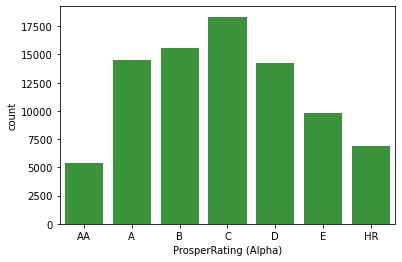

```python
base_color = sns.color_palette()[2]
sns.countplot(prosper_loan['ProsperRating (Alpha)'],color=base_color);
```

The ProsperRating (Alpha) follows a normal distribution as most of the loans are rated at C, which is the centre of the distribution. The best rating at AA while the least rating at HR

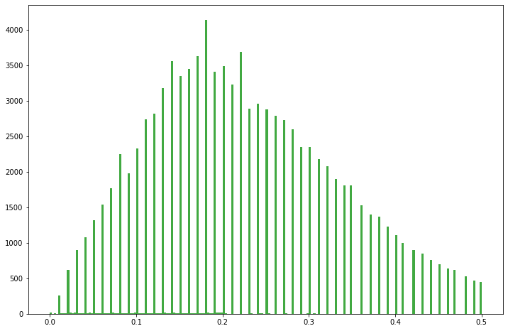

```python
## Distribution of debt to income ratio.
plt.figure(figsize=[12,8])
base_color = sns.color_palette()[2]
bin_edges = np.arange(0,0.5+0.0025,0.0025)
plt.hist(data=prosper_loan,x='DebtToIncomeRatio',bins=bin_edges, color= base_color,alpha=0.9);
```

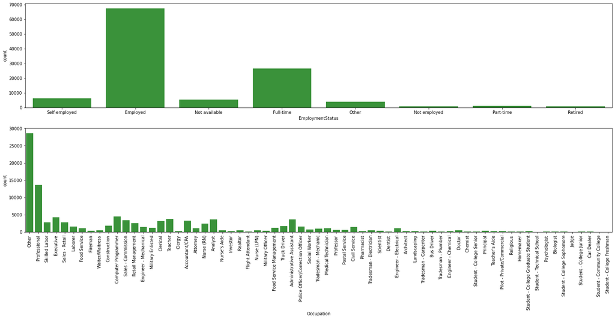

```python
## plotting Employmentstatus and Occupation
plt.figure(figsize=[25,10])
base_color=sns.color_palette()[2]
## 2 row,1columns,
## plot 1
plt.subplot(2,1,1)
sns.countplot(data=prosper_loan,x='EmploymentStatus',color=base_color)
## plot 2
plt.subplot(2,1,2)
sns.countplot(data=prosper_loan,x='Occupation',color=base_color)
plt.xticks(rotation=90);
```

Most borrowed loans are from people who are employed, then followed by full-time,self-employed,not-available,other,part-time,not-employed and retired. Most loans were borrowed by people who had other and professional occupation.Judges,student college junior and student college freshman occupation have very few loan borrowers.

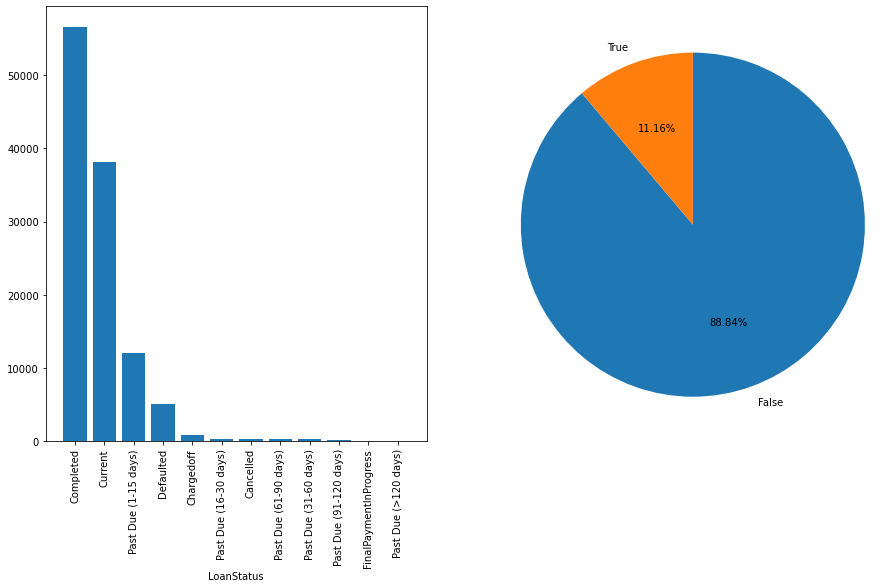

```python
## plotting currentlyingroup and loanstatus variables.
plt.figure(figsize=[15,8])
x=prosper_loan['LoanStatus'].unique()
y=prosper_loan['LoanStatus'].value_counts(sort=True)
plt.subplot(1,2,1)
plt.bar(x,y)
plt.xlabel('LoanStatus')
plt.xticks(rotation=90)
plt.subplot(1,2,2)
sorted_counts = prosper_loan['CurrentlyInGroup'].value_counts()
plt.pie(sorted_counts,labels=sorted_counts.index,startangle =90,counterclock=False,autopct='%1.2f%%')
plt.axis('square');
```

Most loans are on completed and on current stages.With few loans in finalpaymentinprogress and pastdue(>120 days).

##### plotting the distribution of statedmonthlyincome,totaltrades,openrevolvingamount,tradesneverdeliquent,currentdeliquencies and ontimeprosperpayments.

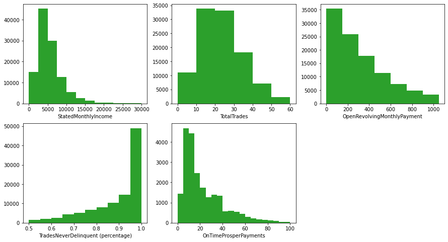

```python
plt.figure(figsize=[15,8])
base_color = sns.color_palette()[2]
plt.subplot(2,3,1)
bins=np.arange(0,30000+2500,2500)
plt.hist(data=prosper_loan,x='StatedMonthlyIncome',color=base_color,bins=bins)
plt.xlabel('StatedMonthlyIncome')
plt.subplot(2,3,2)
bins=np.arange(0,60+10,10)
plt.hist(data=prosper_loan,x='TotalTrades',color=base_color,bins=bins)
plt.xlabel('TotalTrades')
plt.subplot(2,3,3)
bins=np.arange(0,1000+150,150)
plt.hist(data=prosper_loan,x='OpenRevolvingMonthlyPayment',color=base_color,bins=bins)
plt.xlabel('OpenRevolvingMonthlyPayment')
plt.subplot(2,3,4)
bins=np.arange(0.5,1+0.05,0.05)
plt.hist(data=prosper_loan,x='TradesNeverDelinquent (percentage)',color=base_color,bins=bins)
plt.xlabel('TradesNeverDelinquent (percentage)')
plt.subplot(2,3,5)
bins= np.arange(0,100+5,5)
plt.hist(data=prosper_loan,x='OnTimeProsperPayments',color=base_color,bins=bins)
plt.xlabel('OnTimeProsperPayments');
```

- plot 1 : As the statedmonthlyincomes increases from 0 to 2500 to 5000, the amount of loans also increases, but as the statedmonthlyincomes increases from 5000 to 30000, the amount of loans keeps on decreasing.
- plot 2 : Most loans have 20 and 30 total trades with the least loans having 60 total trades.
- plot 3 : Openrevolvingmonthlypayment follows a right-skewed distribution with most of the loans having an openrevolvingamount of between 0-200.
- plot 4 : Tradesneverdeliquent(percentage) follows a left-skewed distribution with most of the loans having trades that have never been deliquent.
- plot 5 : Most loans have 10 ontimeprosperpayments.As the ontimeprosperpayment increases from 0-10, the amount of loans also increases.As from 15 to 30 ontimeprosperpayments the loan amount keeps on decreasing.At 35, the loan amount increases slightly and then starts to decrease again.

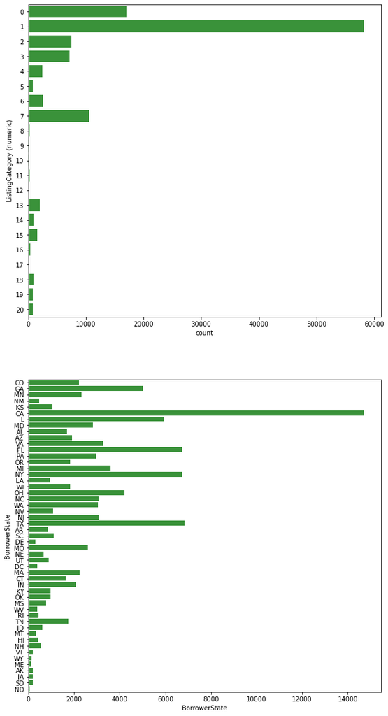

```python
## Listing Category and Borrower State Distribution.
plt.figure(figsize=[10,20])
base_color = sns.color_palette()[2]
plt.subplot(2,1,1)
sns.countplot(data=prosper_loan,y='ListingCategory (numeric)',color=base_color)
plt.ylabel('ListingCategory (numeric)')
plt.subplot(2,1,2)
sns.countplot(data=prosper_loan,y='BorrowerState',color=base_color)
plt.xlabel('BorrowerState')
plt.show();
```

- plot 1 : Most people borrow loans for the purposes of debt consolidation.A quite a number borrower for other pursoses and some their listing is not available
- plot 2 : High number of People from CA borrowed loans. People from GA,IL,FL,NY and TX also have a high borrowing counts.

#### Discuss the distribution(s) of your variable(s) of interest.

The prosperrating (Alpha) appears to follow a normal distribution with most loans rated at C.Loans with prosperrating B,A and AA are higher than loans with prosperrating HR,E and D.

#### Were there any unusual points?.

No, they were no unusual points.

#### Did you need to perform any transformations

No.

#### Of the features you investigated, were there any unusual disstributions.Did you perform any operations on the data to tidy, adjust or change the form of the data? if so , why did you do this.

There were no unusual distributions.

### Bivariate Exploration

#### Pairwise Relationships between the features.

```python
categorical_variables =['ProsperRating (Alpha)','LoanStatus','ListingCategory','EmploymentStatus']
numerical_variables = ['DebtToIncomeRatio','StatedMonthlyIncome','TotalTrades','OnTimeProsperPayments']
```

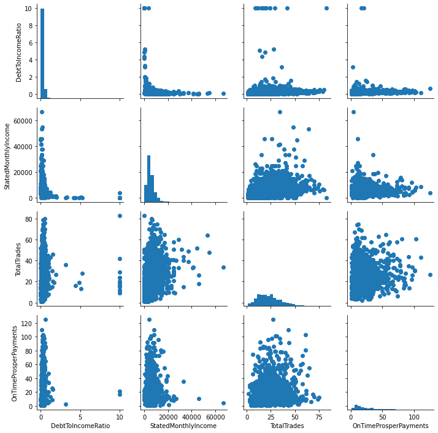

```python
##  plotting a pairgrid.
## using a subset of the data
prosper_loan_sub = prosper_loan.sample(n=5000)
a= sns.PairGrid(data=prosper_loan_sub, vars = numerical_variables)
a = a.map_diag(plt.hist,bins=25)
a.map_offdiag(plt.scatter);
```

```python
### plotting a heatmap to see the correlation coefficients between the numerical variables.
def heatMap():
    """
    This is a function that gives a heat plot of the numerical variables.

    cmin is used to set a minimum bound of counts
    cmap is used to reverse the color map
    """
    sns.heatmap(prosper_loan[numerical_variables].corr(),  annot = True, fmt = '.2f', cmap = "inferno",center= 0)
    plt.show();
```

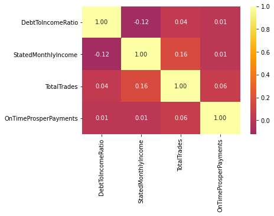

```python
heatMap()
```

### Relationships between Categorical Variables.

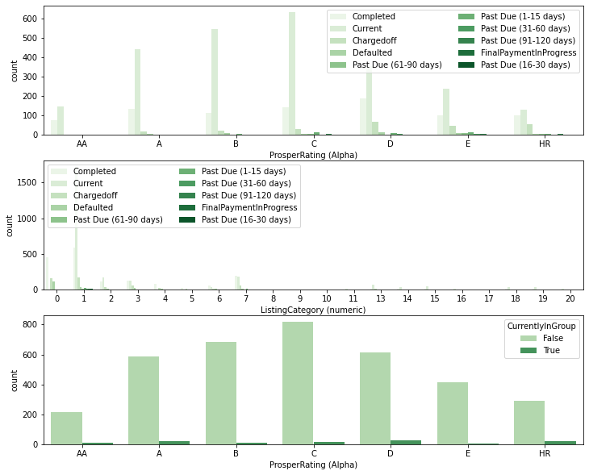

```python
## ProsperRating(Alpha) is a  categorical variable, thus will plot a bargraph.
plt.figure(figsize=[12,10])
g= plt.subplot(3,1,1)
sns.countplot(data=prosper_loan_sub,x='ProsperRating (Alpha)',hue='LoanStatus',palette = 'Greens')
g.legend(ncol=2)
g= plt.subplot(3,1,2)
sns.countplot(data=prosper_loan_sub,x='ListingCategory (numeric)',hue='LoanStatus',palette='Greens')
g.legend(ncol = 2)
plt.subplot(3,1,3)
sns.countplot(data=prosper_loan_sub,x='ProsperRating (Alpha)',hue='CurrentlyInGroup',palette='Greens')
plt.show();
```

Most loans on each rating were under current status. Most of the borrowers are not in groups.

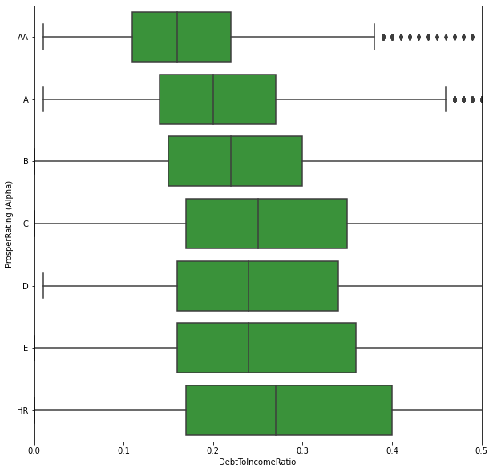

```python
 ## Relationship between prosperrating(alpha) and debt to income ratio
plt.figure(figsize=[10,10])
base_color=sns.color_palette()[2]
sns.boxplot(data=prosper_loan, x='DebtToIncomeRatio',y='ProsperRating (Alpha)',color=base_color)
plt.xlim(0,0.5)
plt.show();
```

As the debt to income ratio decreases the prosper rating (Alpha) becomes better.

#### Relationship Between ProsperRating (Alpha) vs StatedMonthlyincome and ProsperRating (Alpha) vs TotalTrades.

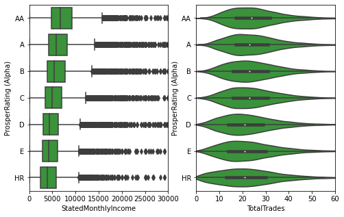

```python
plt.figure(figsize=[8,5])
base_color = sns.color_palette()[2]
plt.subplot(1,2,1)
sns.boxplot(data=prosper_loan,x='StatedMonthlyIncome',y= 'ProsperRating (Alpha)',color=base_color)
plt.xlim(0,30000)
plt.subplot(1,2,2)
sns.violinplot(data=prosper_loan,x='TotalTrades',y='ProsperRating (Alpha)',color=base_color)
plt.xlim(0,60)
plt.show();
```

- plot 1 : An increase in the statedmontlyincomes leads to an improvement in the ratings.That is the ratings keeps on getting better.
- plot 2 : As the totaltrades remains constant at 20,the ratings improve from HR to E to D.As the totalTrades increases from 20, the ratings get better from C to B to A to AA.

#### How did the feature of interest vary with other features in the dataset?

- For the relationship between prosperrating(Alpha) and debttoincomeratio,we see a negative relationship.This is because as the debt to income ratio decreases the ratings also get better. That is loans with the least debt to income ratio have the best rating.
- For the relationship between prosperrating(Alpha) and statedmonthlyincome,a positive association was observed with better ratings given to prosperloans with higher statedmonthlyincomes.
- For prosperrating(Alpha) vs totaltrades, we see an interesting relationship because at 20 total trades the ratings improve from HR to E then D.As the totaltrades starts to increase slowly, the ratings keeps on getting better.
- prosperloans that were on current status were mostly rated.
- Most borrowers that were not in groups were rated at C while those that were in groups,were highest at rating D.

#### Did you observe any interesting relationships between the other features(That is not the main feature of interest).

- A negative association is seen statedmonthlyincomes and debt to income ratio, this means as the income increases the debt to income ratio decreases.
- There is also a positive relationship between statedmonthlyincome and totaltrade.As the income increases the number of trades also increases.
- For ontimeprosperpayment vs debttoincomeratio, ontimeprosperpayment vs statedmonthlyincome, ontimeprosperpayment vs totaltrades, there is a weak positive relationship.

## Multivariate Exploration.

[output not shown]

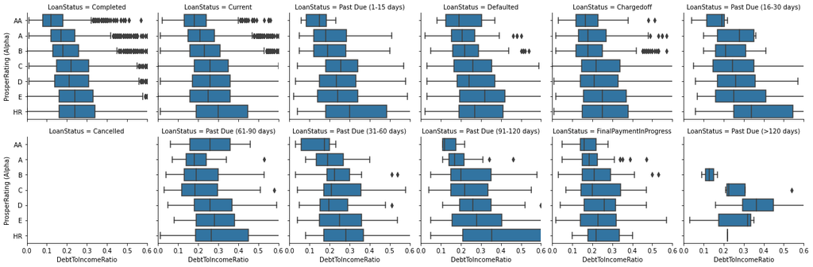

```python
## Effects of  LoanStatus on the relationship between DebtToIncomeRatio and  prosper ratings(Alpha).
plt.figure(figsize=[10,10])
a = sns.FacetGrid(data=prosper_loan, col = 'LoanStatus',size=3,col_wrap=6)
a.map(sns.boxplot,'DebtToIncomeRatio','ProsperRating (Alpha)')
plt.xlim(0,0.6)
plt.show();
```

For loans that are completed, current and chargedoff, as the debttoincomeratio decreases, the ratings get better.This pattern is also seen when the loan is pastdue by 91-120 days.For past due(31-60) and (61-90) the debt to income ratio keeps on fluctuating as the ratings get better. Interestingly, for finalpaymentinprogress, as the debttoincomeratio increases the ratings increase from HR to E to D,after the centre (C) the debttoincome ratio decreases with increase in ratings. For loans past due(>120days), there are no best ratings that is A and AA.

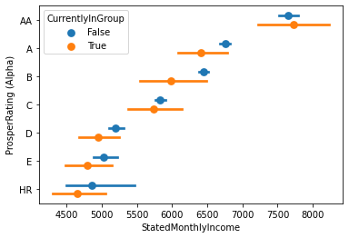

```python
## Effect of currently in group on the relationship of statedmonthlyincome and ProsperRating (Alpha)
sns.pointplot(data=prosper_loan,x='StatedMonthlyIncome',y='ProsperRating (Alpha)',
              hue='CurrentlyInGroup',dodge=0.3,linestyles = "");
```

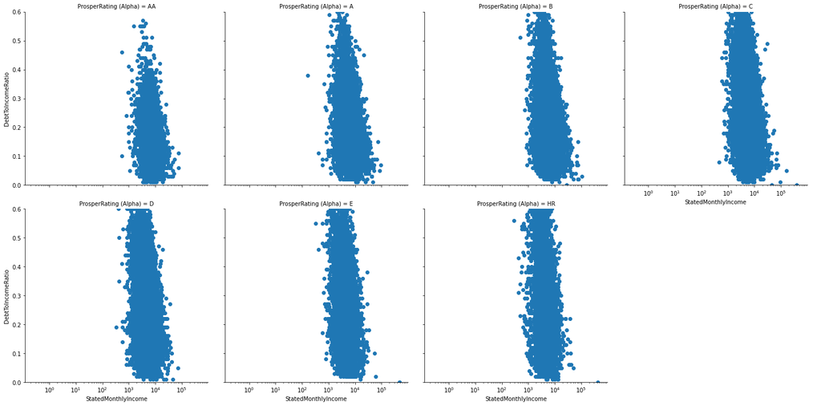

```python
## ProsperRating on statedMonthlyIncome vs DebtToIncomeRatio.
plt.figure(figsize=[12,8])
g= sns.FacetGrid(data=prosper_loan,col='ProsperRating (Alpha)',height=5,col_wrap=4)
g.map(plt.scatter, 'StatedMonthlyIncome','DebtToIncomeRatio')
plt.ylim(0,0.6)
plt.xscale('log')
g.add_legend()
```

The ratings keeps on getting better as the debt to income ratio decreases with increase in statedmonthlyincome.

#### Talk about some of the relationships you observed in this part of the investigation.Were there features that strengthened each other in terms of looking at your feature of interest?

- I investigated the effect of loan status on the relationship between prosperrating and debt to income ratio.The relationship in each status differed with the other slightly, but the overall observation was that the loans that were completed had a lower debt to income ratio thus a better rating.I also checked on the effect of currentlyingroup on prosperrating and statedmonthlyincome and found that as the incomes increases the rating becomes better as well.Borrowers who were not in groups had a higher income than those in groups from rating HR to A,but at rating AA,the incomes of those in groups is slightly higher than those not in groups.
- For relationship between prosperrating,statedmonthlyincomes and debt to income ratio, an increase in statedmonthlyincomes leads to the decrease of debt to income ratio therefore receiving a better rating.I transformed my x variable(statedmonthlyincome) to be able to see where most of the points are clearly.

#### Were there any interesting interactions between features?

For the effect of currentlyingroup on the relationship between prosperrating and statedmonthlyincome, we see an interesting interaction between those in groups and those not in groups.Those not in groups have a higher incomes from rating HR to A, but at rating AA, the incomes of those in groups is higher than those not in groups.Overally,an increase in income leads to a better prosper rating.

```python
prosper_loan['LoanStatus'].value_counts()
```

```
Current                   56576
Completed                 38074
Chargedoff                11992
Defaulted                  5018
Past Due (1-15 days)        806
Past Due (31-60 days)       363
Past Due (61-90 days)       313
Past Due (91-120 days)      304
Past Due (16-30 days)       265
FinalPaymentInProgress      205
Past Due (>120 days)         16
Cancelled                     5
Name: LoanStatus, dtype: int64
```